# Assignment 2

B166247

3 3 2020

# Problem 1

## (a)

Create data table results.dt by reading the results file, and annotate each lipid species with its corresponding full class name. Count the number of lipids that fall in each class listed in the lipid-classes.txt file.

```r
#loading the required library
library(data.table)

#loading the files
lipids.dt <- data.table(read.delim("lipids.txt"))
classes.dt <- data.table(read.delim("lipid-classes.txt"))

#lipid classes can be found in the first column of lipids.dt
#Finding all lipids PC and assignment to new column lipid.class (42)
lipids.dt[grep("^[Pp]C", lipid.species), lipid.class := classes.dt[CE == "PC", Cholesterol.esters]]
#Finding all Cer (11)
lipids.dt[grep("^[Cc]er|CER", lipid.species), lipid.class := classes.dt[CE == "Cer", Cholesterol.esters]]
#Finding all DAG (16)
lipids.dt[grep("^[Dd]ag|DAG", lipid.species), lipid.class := classes.dt[CE == "DAG", Cholesterol.esters]]
#Finding all LPC (13)
lipids.dt[grep("^[Ll]pc|LPC", lipid.species), lipid.class := classes.dt[CE == "LPC", Cholesterol.esters]]
#Finding all LPE (3)
lipids.dt[grep("^[Ll]pe|LPE", lipid.species), lipid.class := classes.dt[CE == "LPE", Cholesterol.esters]]
#Finding all PE (25)
lipids.dt[grep("^[Pp]e|^PE", lipid.species), lipid.class := classes.dt[CE == "PE", Cholesterol.esters]]
#Finding all PS (8)
lipids.dt[grep("^[Pp]s|^PS", lipid.species), lipid.class := classes.dt[CE == "PS", Cholesterol.esters]]
#Finding all SM (0)
lipids.dt[grep("[Ss]m|SM", lipid.species)]
```

```
## Empty data.table (0 rows and 4 cols): lipid.species,oddsratio,se,lipid.class
```

```r
#Finding all TAG (147)
lipids.dt[grep("[Tt]ag|TAG", lipid.species), lipid.class := classes.dt[CE == "TAG", Cholesterol.esters]]

#it can be seen that 9 rows are still unoccupied (correspond to CE)
lipids.dt[is.na(lipid.class)]
```

```
##    lipid.species oddsratio      se lipid.class
## 1:       CE 18:2      1.06 0.12881        <NA>
## 2:       CE 16:1      1.11 0.12886        <NA>
## 3:       CE 20:4      0.92 0.13149        <NA>
## 4:       CE 18:3      1.16 0.12524        <NA>
## 5:       CE 18:0      0.99 0.08333        <NA>
## 6:       CE 14:1      0.92 0.12219        <NA>
## 7:       CE 22:6      0.71 0.12850        <NA>
## 8:       CE 16:0      1.07 0.11520        <NA>
## 9:       CE 14:0      0.96 0.12301        <NA>
```

After adding all classes provided in the classes.txt file, it can be seen that one class is missing and 9 rows with the abbreviation CE could not be annotated. Following the shorthand notation of lipids published by Liebisch et al. in 2013 CE corresponds to Cholesteryl ester (Liebisch et al., 2013). I added this class manually.

```r
#manual addition of Cholesteryl ester
lipids.dt[grep("\\b[C]e\\b|\\bCE\\b", lipid.species), lipid.class := "Cholesteryl ester"]
#test that all lipids have a class
stopifnot(!is.na(lipids.dt$lipid.class))

#count the number of entries corresponding to each class (one class missing only 8!)
lipids.dt[, .(count = .N), lipid.class]
```

```
##                      lipid.class count
## 1:          Phosphatidylcholines    42
## 2:              Triacylglycerols   147
## 3:             Cholesteryl ester     9
## 4:     Phosphatidylethanolamines    25
## 5:           Phosphatidylserines     8
## 6:      Lysophosphatidylcholines    13
## 7:                     Ceramides    13
## 8:               Diacylglycerols    16
## 9: Lysophosphatidylethanolamines     3
```

## (b)

Compute the Wald test statistic for each lipid species. Assuming that there were 288 patients in the dataset, derive a p-value for each lipid species using the t distribution and append them to the results.dt data table (please then use the t distribution in parts c and d of this problem). Repeat the computation of the p-values using the normal distribution (hint: you’ll need to use the pnorm() function). Present some evidence to justify if the normal approximation is acceptable in this instance. Since there are 9 lipid species in the table (including CE and exclusing SM), they are calculated as following:

```r
#calculate the Wald test (t-distributed)
lipids.dt[, "Wald.test(t.dist)":= round(((oddsratio-1)/se), 3)]

#calculate the degress of freedom
df <- 288-9-1

#calculate the p-value based on the t-distribution
lipids.dt[, "p.value.t" := signif(2*pt(abs(`Wald.test(t.dist)`), df, lower.tail = FALSE), 4)]

#calculate the p-value based on the normal distribution
results.dt <- lipids.dt[, "p.value.norm" := signif(2*pnorm(`Wald.test(t.dist)`, lower.tail = FALSE), 4)]

#checking the table
head(results.dt)
```

```
##       lipid.species oddsratio      se          lipid.class Wald.test(t.dist)
## 1:          PC 34:6      1.79 0.13662 Phosphatidylcholines             5.782
## 2:          PC 34:5      0.74 0.12452 Phosphatidylcholines            -2.088
## 3: 18:2 820 TAG C48      0.89 0.12213     Triacylglycerols            -0.901
## 4: 16:2 870 TAG C52      0.78 0.12435     Triacylglycerols            -1.769
## 5: 16:1 842 TAG C50      0.92 0.11752     Triacylglycerols            -0.681
## 6:          PC 42:5      0.90 0.12413 Phosphatidylcholines            -0.806
##    p.value.t p.value.norm
## 1: 1.981e-08    7.382e-09
## 2: 3.771e-02    1.963e+00
## 3: 3.684e-01    1.632e+00
## 4: 7.799e-02    1.923e+00
## 5: 4.964e-01    1.504e+00
## 6: 4.209e-01    1.580e+00
```

Present some evidence to justify if the normal approximation is acceptable in this instance.

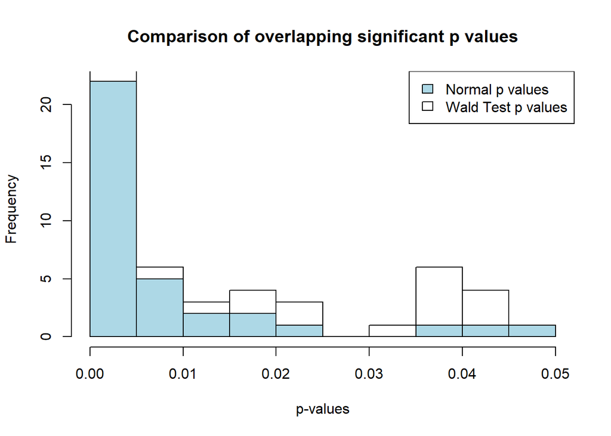

```r
#select cases where t distribution is below 0.05
nt.extreme <- results.dt[p.value.t<0.05 & p.value.norm<0.05]
t.extreme <- results.dt[p.value.t<0.05]

#creating the plot
hist1 <- hist(nt.extreme$p.value.t, plot=FALSE)
hist2 <- hist(t.extreme$p.value.t, plot=FALSE)

plot(hist1, main="Comparison of overlapping significant p values", xlab = "p-values", col="lightblue")
plot(hist2, add=TRUE)
legend("topright", legend=c("Normal p values", "Wald Test p values"), fill = c("lightblue", "white"))
```

## (c)

Implement the following function: *holm.bonferroni <- function(results.dt, alpha)* where results.dt is a data table containing the hypotheses tested and corresponding p-values, and alpha is the desired significance level. The function should return the subset of results.dt that are significant according to the Holm-Bonferroni method ordered by increasing p-value.

```r
holm.bonferroni <- function(results.dt, alpha){
  #copy and order the input dataframe
  order.dt <- results.dt[order(p.value.t),]

  #looping through all sorted entries
  for (row.idx in seq(1,nrow(order.dt))){
    #calculate the threshhold value for the row
    pcalc <- alpha/(276+1-row.idx)
    #cat(pcalc)
    #testing if the threshold is passed
    if (pcalc >= order.dt[row.idx, p.value.t]) {
      #threshold is not passed anymore and the loop breaks
      lastidx <- row.idx
      #cat(lastidx, "\n")
      #cat("This is the pcalc ", pcalc)
    } else {
      #nothting happens when the pcalc gets too large
    }
  }

  #returning the subset of the ordered table
  return(order.dt[1:lastidx])
}
```

## (d)

Write the following function: *benjamini.hochberg <- function(results.dt, q)* that implements the Benjamini-Hochberg procedure and, given data table results.dt of hypotheses and p-values and a false discovery rate q, returns the subset of results.dt that are significant ordered by increasing p-value.

```r
benjamini.hochberg <- function(results.dt, q){
  q <- 0.01
  #copy and order the input dataframe
  order.dt <- results.dt[order(p.value.t),]

  #looping through all sorted entries
  for (row.idx in seq(1,nrow(order.dt))){
    pcalc <- (row.idx/276)*q

    #testing if the threshold is valid
    if (pcalc > order.dt[row.idx, p.value.t]){
      #assigning the indeces that pass the threshold
      lastidx <- row.idx
      #cat(lastidx, "\n")
      #cat("This is the pcalc ", pcalc)
    } else {
      #pass as the threshold was passed
    }

  }

  #return the subset in ascending p value order
  return(order.dt[1:lastidx])

}
```

## (e)

Produce a volcano plot using a different colour for the lipid species that are significant after controlling for the family-wise error rate given a nominal significance threshold alpha = 0.05 (it is not required to display names alongside the highlighted points). Use a different symbol to highlight the points that are considered significant according to the Benjamini-Hochberg procedure at a false discovery rate of 1%.

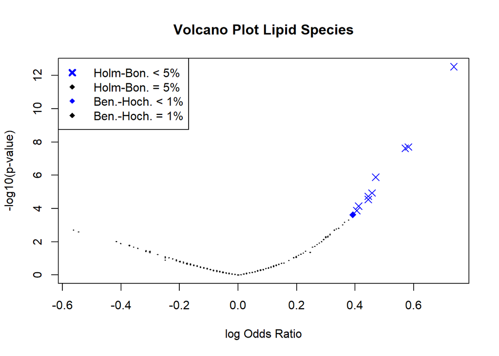

```r
#finding the subsets that are significant
sigholm <- holm.bonferroni(results.dt, 0.05)
sigben <- benjamini.hochberg(results.dt, 0.01)

#plot the volcano plot
plot(log(results.dt$oddsratio), -log10(results.dt$p.value.t), main = "Volcano Plot Lipid Species",
     xlab = "log Odds Ratio",
     ylab = "-log10(p-value)",
     col = ifelse(results.dt$p.value.t %in% c(sigholm$p.value.t, sigben$p.value.t),"blue", "black" ),
     pch = ifelse(results.dt$p.value.t %in% sigholm$p.value.t, 4, 18),
     cex=ifelse((results.dt$p.value.t %in% sigholm$p.value.t | results.dt$p.value.t %in% sigben$p.value.t), 1.3, 0.3))

#add legend
legend("topleft", c("Holm-Bon. < 5%", "Holm-Bon. ≥ 5%", "Ben.-Hoch. < 1%", "Ben.-Hoch. ≥ 1%"),
       col = c("blue","black", "blue", "black"),
       lwd = c(3,1,5,1),
       lty = c(NA,NA,NA,NA),
       pch = c(4,18,18,18))
```

## (f)

Use the two functions to determine the subsets of lipid species that are considered significant according to either method (use alpha = 0.05 for the Holm-Bonferroni method, and q = 0.05 for the Benjamini-Hochberg procedure). Provide tables of each of function outputs. Holm Bonferroni

```r
#Lipid Species that are significant after family wise error rate of 0.05
holmlipid.dt <- holm.bonferroni(lipids.dt, 0.05)
holmlipid.dt
```

```
##     lipid.species oddsratio      se          lipid.class Wald.test(t.dist)
##  1:       PS 36:4      2.09 0.14212  Phosphatidylserines             7.670
##  2:       PC 34:6      1.79 0.13662 Phosphatidylcholines             5.782
##  3:       PS 38:5      1.77 0.13395  Phosphatidylserines             5.748
##  4:       PC 34:2      1.60 0.12132 Phosphatidylcholines             4.946
##  5:       PC 36:2      1.58 0.12987 Phosphatidylcholines             4.466
##  6:       PS 38:6      1.56 0.12846  Phosphatidylserines             4.359
##  7:       PS 38:4      1.56 0.13168  Phosphatidylserines             4.253
##  8:       PS 40:6      1.51 0.12657  Phosphatidylserines             4.029
##  9:       PC 42:1      1.50 0.12885 Phosphatidylcholines             3.880
## 10:       PC 34:0      1.50 0.12899 Phosphatidylcholines             3.876
##     p.value.t p.value.norm
##  1: 2.909e-13    1.720e-14
##  2: 1.981e-08    7.382e-09
##  3: 2.372e-08    9.031e-09
##  4: 1.313e-06    7.575e-07
##  5: 1.160e-05    7.970e-06
##  6: 1.841e-05    1.307e-05
##  7: 2.884e-05    2.109e-05
##  8: 7.235e-05    5.601e-05
##  9: 1.305e-04    1.045e-04
## 10: 1.325e-04    1.062e-04
```

Benjamin Hochberg

```r
#Lipid Species significant after false recovery rate of 0.05
benjaminlipid.dt <- benjamini.hochberg(lipids.dt, 0.05)
benjaminlipid.dt
```

```
##     lipid.species oddsratio      se          lipid.class Wald.test(t.dist)
##  1:       PS 36:4      2.09 0.14212  Phosphatidylserines             7.670
##  2:       PC 34:6      1.79 0.13662 Phosphatidylcholines             5.782
##  3:       PS 38:5      1.77 0.13395  Phosphatidylserines             5.748
##  4:       PC 34:2      1.60 0.12132 Phosphatidylcholines             4.946
##  5:       PC 36:2      1.58 0.12987 Phosphatidylcholines             4.466
##  6:       PS 38:6      1.56 0.12846  Phosphatidylserines             4.359
##  7:       PS 38:4      1.56 0.13168  Phosphatidylserines             4.253
##  8:       PS 40:6      1.51 0.12657  Phosphatidylserines             4.029
##  9:       PC 42:1      1.50 0.12885 Phosphatidylcholines             3.880
## 10:       PC 34:0      1.50 0.12899 Phosphatidylcholines             3.876
## 11:       PC 36:3      1.48 0.12882 Phosphatidylcholines             3.726
## 12:       PS 34:4      1.48 0.12888  Phosphatidylserines             3.724
##     p.value.t p.value.norm
##  1: 2.909e-13    1.720e-14
##  2: 1.981e-08    7.382e-09
##  3: 2.372e-08    9.031e-09
##  4: 1.313e-06    7.575e-07
##  5: 1.160e-05    7.970e-06
##  6: 1.841e-05    1.307e-05
##  7: 2.884e-05    2.109e-05
##  8: 7.235e-05    5.601e-05
##  9: 1.305e-04    1.045e-04
## 10: 1.325e-04    1.062e-04
## 11: 2.356e-04    1.945e-04
## 12: 2.374e-04    1.961e-04
```

```r
lipid.inter <- which(results.dt$lipid.species %in% intersect(holmlipid.dt$lipid.species, benjaminlipid.dt$lipid.species))
results.dt[lipid.inter]
```

```
##     lipid.species oddsratio      se          lipid.class Wald.test(t.dist)
##  1:       PC 34:6      1.79 0.13662 Phosphatidylcholines             5.782
##  2:       PS 38:4      1.56 0.13168  Phosphatidylserines             4.253
##  3:       PS 38:5      1.77 0.13395  Phosphatidylserines             5.748
##  4:       PC 34:2      1.60 0.12132 Phosphatidylcholines             4.946
##  5:       PS 36:4      2.09 0.14212  Phosphatidylserines             7.670
##  6:       PC 36:2      1.58 0.12987 Phosphatidylcholines             4.466
##  7:       PC 42:1      1.50 0.12885 Phosphatidylcholines             3.880
##  8:       PS 40:6      1.51 0.12657  Phosphatidylserines             4.029
##  9:       PC 34:0      1.50 0.12899 Phosphatidylcholines             3.876
## 10:       PS 38:6      1.56 0.12846  Phosphatidylserines             4.359
##     p.value.t p.value.norm
##  1: 1.981e-08    7.382e-09
##  2: 2.884e-05    2.109e-05
##  3: 2.372e-08    9.031e-09
##  4: 1.313e-06    7.575e-07
##  5: 2.909e-13    1.720e-14
##  6: 1.160e-05    7.970e-06
##  7: 1.305e-04    1.045e-04
##  8: 7.235e-05    5.601e-05
##  9: 1.325e-04    1.062e-04
## 10: 1.841e-05    1.307e-05
```

# Problem 2

## (a)

Using package caret, create a data partition so that the training set contains 70% of the observations (set the random seed to 1 beforehand). Fit both a ridge regression model and a lasso model on the training set to diagnose the type of tumour from the 30 biomarkers: for each model learn by cross-validation the penalty parameter lambda that maximizes the AUC.

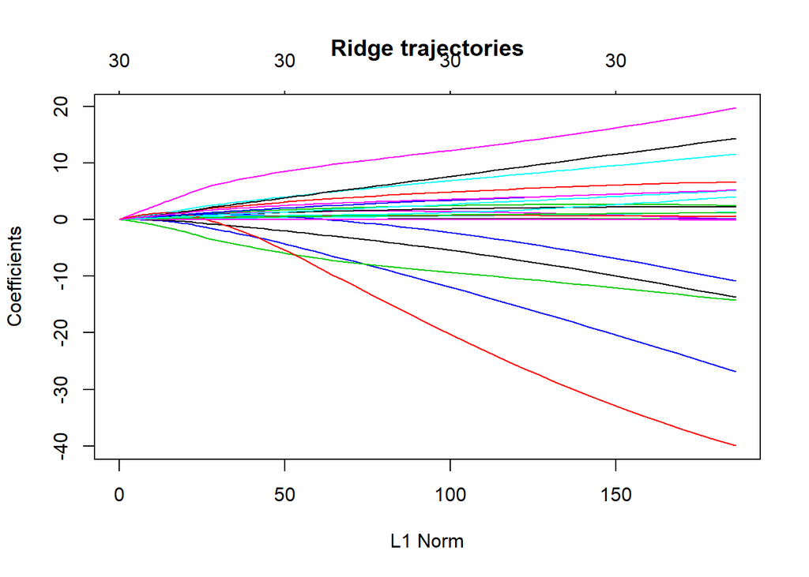

```r
#loading the required libraries
library(caret)
library(pROC)
library(glmnet)

#load the data set
wdbc2.dt <- fread("wdbc2.csv", stringsAsFactors = TRUE)

#setting the seed
set.seed(1)

#create the data particioning
train.idx <- createDataPartition(wdbc2.dt$diagnosis, p=0.7)$Resample1

#function from lab 4 to convert data tables into a matrix as expected by glmnet
prepare.glmnet <- function(data, formula=~ .) {
  ## create the design matrix to deal correctly with factor variables,
  ## without losing rows containing NAs
  old.opts <- options(na.action='na.pass')
  x <- model.matrix(formula, data)
  options(old.opts)
  ## remove the intercept column, as glmnet will add one by default
  x <- x[, -match("(Intercept)", colnames(x))]
  return(x)
}

#separate desig matrix from outcomes
ywdbc2.dt <- as.matrix(wdbc2.dt$diagnosis)
xwdbc2.dt <- prepare.glmnet(wdbc2.dt[, !"id"], ~ . -diagnosis )


#fit ridge regression model with cross validation
fit.ridge <- glmnet(xwdbc2.dt, ywdbc2.dt, family="binomial", alpha=0, subset = train.idx)
#fit regression with lasso penalty
fit.lasso <- glmnet(xwdbc2.dt, ywdbc2.dt, family="binomial", subset = train.idx)

#plotting coefficients for lambda regression
plot(fit.ridge, main="Ridge trajectories")
```

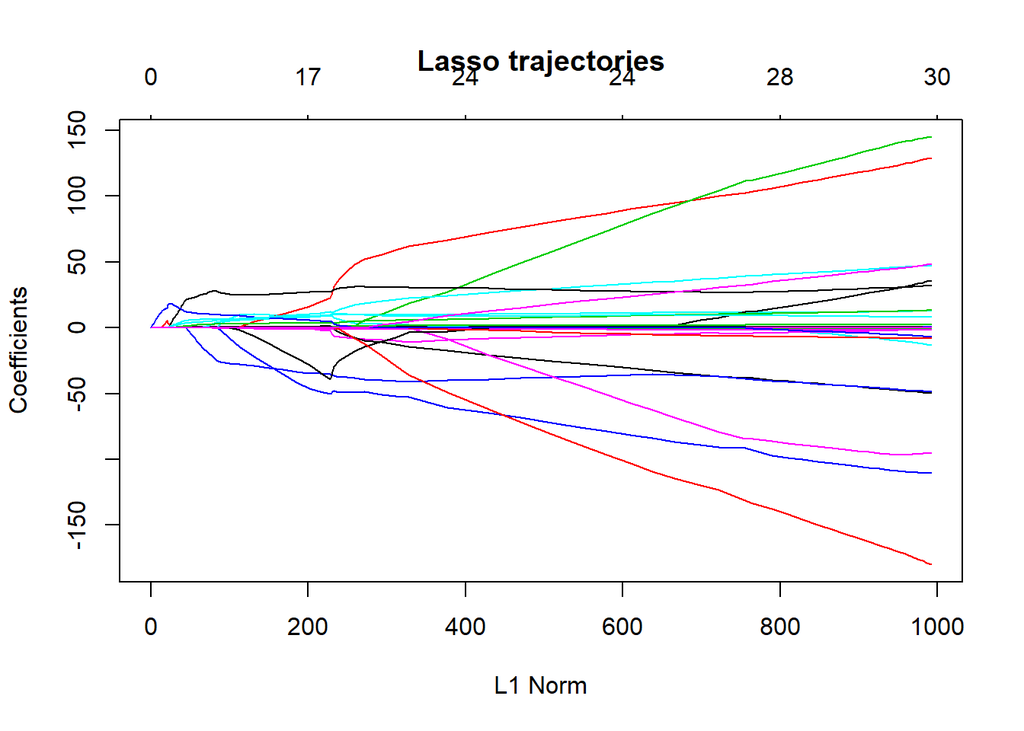

```r
plot(fit.lasso, main="Lasso trajectories")
```

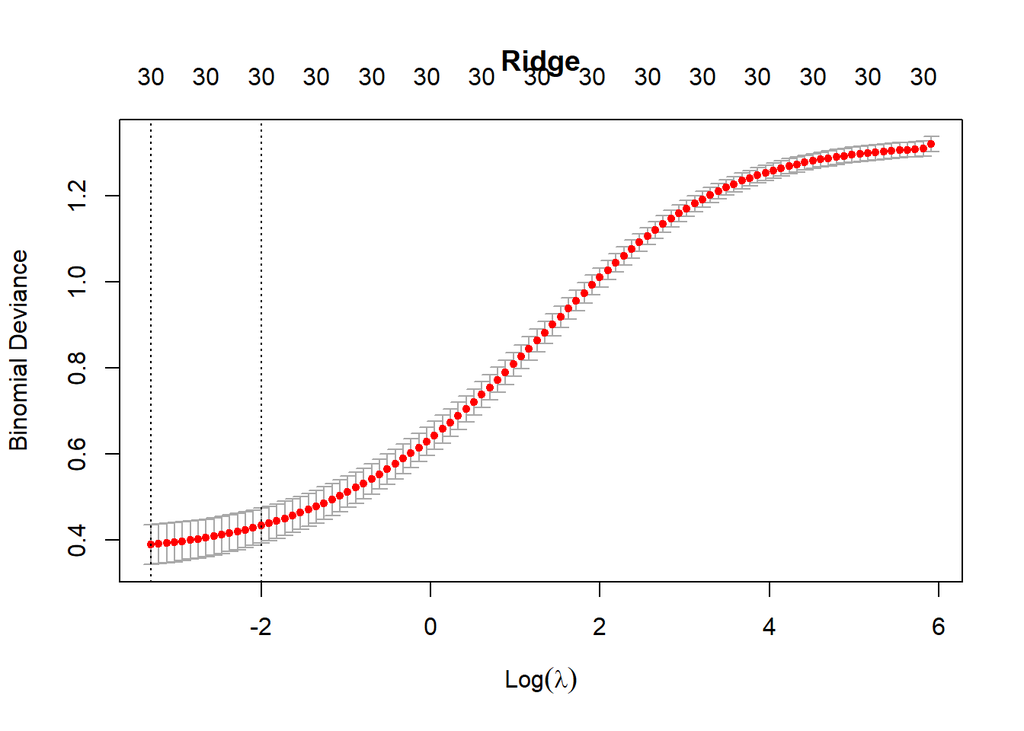

```r
#learning by cross validation
fit.cv.ridge <- cv.glmnet(xwdbc2.dt, ywdbc2.dt, family="binomial", alpha=0, subset = train.idx)
fit.cv.lasso <- cv.glmnet(xwdbc2.dt, ywdbc2.dt, family="binomial", subset = train.idx)

#Plotting the trajectory of the coefficients
plot(fit.cv.ridge, main="Ridge")
```

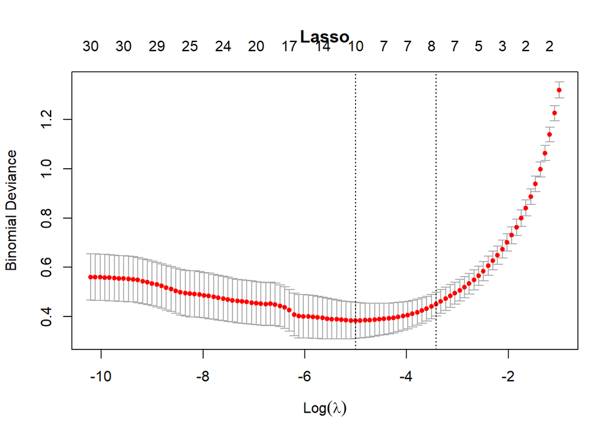

```r
plot(fit.cv.lasso, main="Lasso")
```

## (b)

The AUCs evaluated at all tested values of the penalty parameter (see field lambda) are stored in the cvm field of the object returned by cv.glmnet(). For both models fitted at point (a) extract the AUCs corresponding to the optimal lambda and to the lambda such that the AUC is within 1 standard error of the maximum.

```r
#AUC for best lambda for ridge regression
fit.cv.ridge$cvm[which(fit.cv.ridge$lambda == fit.cv.ridge$lambda.min)]
```

```
## [1] 0.3901684
```

```r
#AUC for best lambda for lasso regression
fit.cv.lasso$cvm[which(fit.cv.lasso$lambda == fit.cv.lasso$lambda.min)]
```

```
## [1] 0.3842018
```

AUC within 1 sd of the maximum

```r
#lasso regression
fit.cv.lasso$cvm[which(fit.cv.lasso$lambda == fit.cv.lasso$lambda.1se)]
```

```
## [1] 0.4504536
```

```r
#ridge regression
fit.cv.ridge$cvm[which(fit.cv.ridge$lambda == fit.cv.ridge$lambda.1se)]
```

```
## [1] 0.4337402
```

## (c)

Create a data table that for each model reports both choices of lambda the corresponding model size, and their training AUC as computed at point (b) (use 3 significant digits for floating point values). Comment on these results.

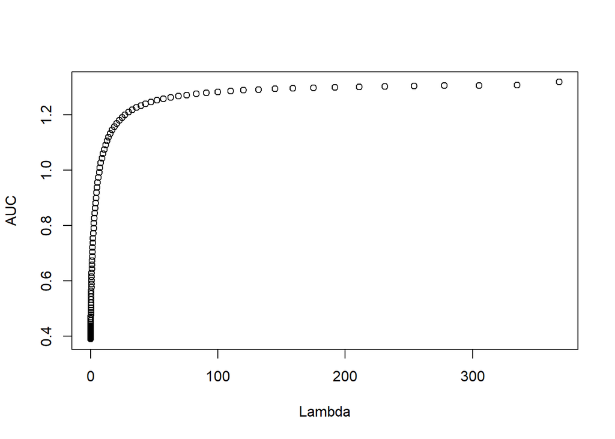

```r
#data table for ridge regression
fit.ridge.dt <- data.table(model.lambda = signif(fit.cv.ridge$lambda,3),
                           model.size = fit.cv.ridge$nzero,
                           model.AUC = signif(fit.cv.ridge$cvm))

#data table for lasso regression
fit.lasso.dt <- data.table(model.lambda = signif(fit.cv.lasso$lambda,3),
                           model.size = fit.cv.lasso$nzero,
                           model.AUC = signif(fit.cv.lasso$cvm, 3))



#plot AUC based onbest lambda
plot(fit.ridge.dt$model.lambda, fit.ridge.dt$model.AUC, xlab = "Lambda", ylab = "AUC")
```

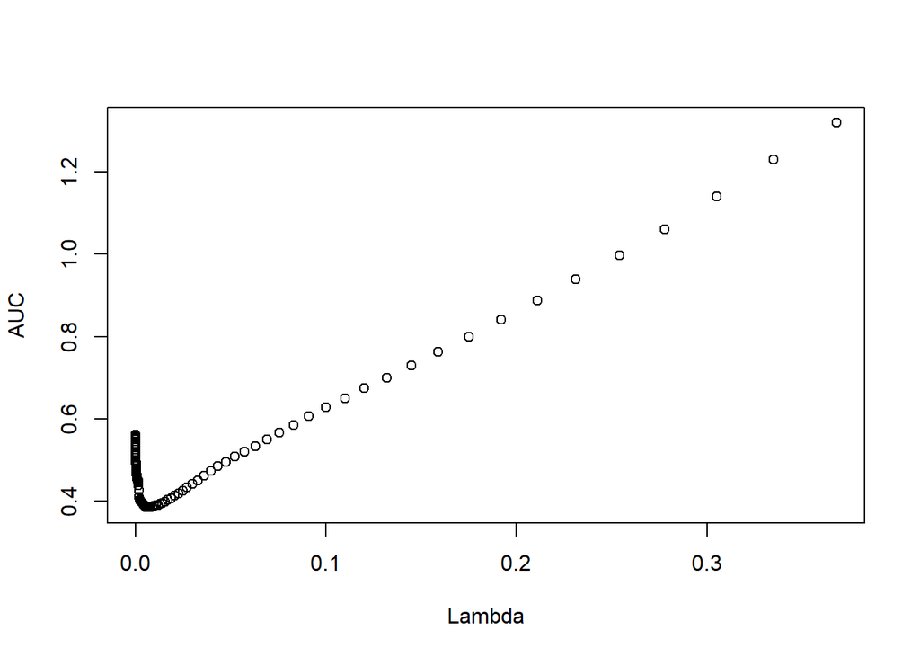

```r
plot(fit.lasso.dt$model.lambda, fit.lasso.dt$model.AUC, xlab = "Lambda", ylab = "AUC")
```

## (d)

Perform backward elimination (we’ll later refer to this as model B) on the same training set derived at point (a). Report the variables selected and their standardized regression coefficients in decreasing order of the absolute value of their standardized regression coefficient. No specific model is specified so the assumption was made that a logistic regression model was meant. Sincce no normalization method for fitted models was found on the internet, the coefficients were normalized following lab 5.

```r
#import library
library(MASS)

#fit logistic regression model on same training data
fit.log <- glm(diagnosis ~ ., data = wdbc2.dt[, !"id"], family = "binomial", subset= train.idx )

#perform backward elimination
log.back <- stepAIC(fit.log, direction="back")
```

```
## Start:  AIC=145.66
## diagnosis ~ radius + texture + perimeter + area + smoothness +
##     compactness + concavity + concavepoints + symmetry + fractaldimension +
##     radius.stderr + texture.stderr + perimeter.stderr + area.stderr +
##     smoothness.stderr + compactness.stderr + concavity.stderr +
##     concavepoints.stderr + symmetry.stderr + fractaldimension.stderr +
##     radius.worst + texture.worst + perimeter.worst + area.worst +
##     smoothness.worst + compactness.worst + concavity.worst +
##     concavepoints.worst + symmetry.worst + fractaldimension.worst
##
##                           Df Deviance    AIC
## - fractaldimension         1   83.665 143.66
## - fractaldimension.worst   1   83.666 143.67
## - texture                  1   83.668 143.67
## - symmetry                 1   83.672 143.67
## - concavepoints.worst      1   83.695 143.69
## - compactness              1   83.708 143.71
## - perimeter.stderr         1   83.716 143.72
## - fractaldimension.stderr  1   83.800 143.80
## - symmetry.worst           1   83.857 143.86
## - area.stderr              1   83.910 143.91
## - smoothness               1   84.108 144.11
## - perimeter.worst          1   84.516 144.52
## - compactness.stderr       1   84.682 144.68
## - smoothness.worst         1   84.703 144.70
## - compactness.worst        1   84.714 144.71
## - symmetry.stderr          1   84.759 144.76
## - radius.worst             1   84.869 144.87
## - perimeter                1   84.989 144.99
## - concavepoints.stderr     1   85.116 145.12
## <none>                         83.665 145.66
## - smoothness.stderr        1   85.815 145.81
## - radius.stderr            1   86.033 146.03
## - texture.stderr           1   86.384 146.38
## - radius                   1   87.016 147.02
## - concavity.worst          1   87.992 147.99
## - area                     1   88.053 148.05
## - texture.worst            1   88.505 148.50
## - concavepoints            1   89.370 149.37
## - concavity                1   89.459 149.46
```

[output cut: 484 more lines]

```
## - concavepoints.stderr  1   91.221 121.22
## - texture.stderr        1   93.334 123.33
## - symmetry.stderr       1   95.236 125.24
## - smoothness.stderr     1   95.287 125.29
## - radius                1   96.758 126.76
## - concavity             1   97.458 127.46
## - area                  1   98.082 128.08
## - concavity.worst       1  100.821 130.82
## - compactness.stderr    1  101.358 131.36
## - concavity.stderr      1  102.396 132.40
## - concavepoints         1  102.747 132.75
## - radius.worst          1  104.813 134.81
## - area.worst            1  107.691 137.69
## - texture.worst         1  109.354 139.35
## - radius.stderr         1  117.644 147.64
```

```r
#required coefficients with their estimate
coef.back <- log.back$coefficients[-1] #excluding the intercept

#scaling the cooefficnets with the standard error
se.coeff <- summary(log.back)$coefficients[-1,2]

#multiplication
scaled.coeff <- coef.back*se.coeff

#report scaled coefficients
scaled.coeff[order(abs(scaled.coeff), decreasing = TRUE)]
```

```
##    smoothness.stderr concavepoints.stderr      symmetry.stderr
##         3.609988e+04        -1.770168e+04         5.580358e+03
##        concavepoints   compactness.stderr            concavity
##         3.911427e+03        -2.518874e+03        -1.028594e+03
##     concavity.stderr      concavity.worst        radius.stderr
##         6.493976e+02         6.362191e+01         3.879020e+01
##         radius.worst       texture.stderr               radius
##         2.455443e+00        -1.989073e+00         1.608002e-01
##        texture.worst           area.worst                 area
##         3.675022e-02        -1.130842e-04        -3.690623e-05
```

## (e)

Repeat the same analysis of point (d) by using stepwise selection (model S) starting from the null model. Report the variables selected and their standardized regression coefficients in decreasing order of the absolute value of their standardized regression coefficient. Did at any point in this procedure occur that a variable entered the model and was later on discarded? If so which?

```r
#difining the null model
null.forward <- glm(diagnosis ~ 1, data=wdbc2.dt[, !"id"], family="binomial", subset = train.idx)

#performing forward selection
log.forward <- stepAIC(null.forward, scope=list(upper=fit.log), direction="forward")
```

```
## Start:  AIC=527.17
## diagnosis ~ 1
##
##                           Df Deviance    AIC
## + perimeter.worst          1   229.75 233.75
## + radius.worst             1   235.73 239.73
## + concavepoints.worst      1   237.34 241.34
## + concavepoints            1   242.84 246.84
## + area.worst               1   254.62 258.62
## + perimeter                1   268.79 272.79
## + radius                   1   274.21 278.21
## + area.stderr              1   293.65 297.65
## + area                     1   297.11 301.11
## + concavity                1   309.39 313.39
## + radius.stderr            1   331.25 335.25
## + perimeter.stderr         1   335.59 339.59
## + concavity.worst          1   342.24 346.24
## + compactness              1   380.30 384.30
## + compactness.worst        1   380.66 384.66
## + texture.worst            1   434.44 438.44
## + texture                  1   444.06 448.06
## + symmetry.worst           1   452.72 456.72
## + concavepoints.stderr     1   453.08 457.08
## + smoothness.worst         1   455.29 459.29
## + smoothness               1   469.90 473.90
## + symmetry                 1   478.39 482.39
## + fractaldimension.worst   1   485.15 489.15
## + compactness.stderr       1   492.10 496.10
## + concavity.stderr         1   497.37 501.37
## + fractaldimension.stderr  1   519.24 523.24
## <none>                         525.17 527.17
## + smoothness.stderr        1   524.16 528.16
## + texture.stderr           1   524.50 528.50
## + symmetry.stderr          1   525.07 529.07
## + fractaldimension         1   525.13 529.13
##
## Step:  AIC=233.75
## diagnosis ~ perimeter.worst
##
##                           Df Deviance    AIC
```

[output cut: 370 more lines]

```
## + concavity                1   98.493 128.49
## + perimeter                1   98.555 128.56
## + texture.stderr           1   98.586 128.59
## + symmetry.stderr          1   98.602 128.60
## + fractaldimension         1   98.713 128.71
## + smoothness.stderr        1   98.806 128.81
## + fractaldimension.stderr  1   98.895 128.90
## + symmetry                 1   98.952 128.95
## + compactness              1   98.971 128.97
## + fractaldimension.worst   1   98.977 128.98
## + concavity.stderr         1   99.003 129.00
## + concavepoints.stderr     1   99.025 129.03
## + concavepoints            1   99.037 129.04
## + perimeter.stderr         1   99.085 129.09
## + smoothness               1   99.112 129.11
```

```r
#no coefficients were selected and then later removed

#final coefficients
log.forward$coefficients[-1]
```

```
##   perimeter.worst  smoothness.worst           texture     radius.stderr
##       0.060420567      65.079663305       0.066474969       8.408541925
##       area.stderr            radius    symmetry.worst     texture.worst
##       0.006578616       0.317651687      12.604728953       0.203226817
##        area.worst      radius.worst   concavity.worst compactness.worst
##      -0.023403530       2.935191083       9.739182457     -12.731808377
##              area
##      -0.004727672
```

```r
#required coefficients with their estimate
coef.forward <- log.forward$coefficients[-1]

#scaling the cooefficnets with the standard error
se.forward <- summary(log.forward)$coefficients[-1,2]

#multiplication
scaled.forward <- coef.forward*se.forward

#report scaled coefficients
scaled.forward[order(abs(scaled.forward), decreasing = TRUE)]
```

```
##  smoothness.worst    symmetry.worst compactness.worst     radius.stderr
##      1.250334e+03      7.007729e+01     -5.764476e+01      2.339975e+01
##   concavity.worst      radius.worst            radius     texture.worst
##      2.302364e+01      2.463747e+00      6.890300e-02      2.477969e-02
##           texture   perimeter.worst       area.stderr        area.worst
##      1.144759e-02      6.088712e-03      1.682303e-04     -1.137147e-04
##              area
##     -1.364065e-05
```

## (f)

Compare the goodness of fit of model B and model S in an appropriate way. The best method for evaluation between the two models would be a log-likelihood test. However, since the two models are not nested, i.e. the forward selection model is not a special case of the backward elimination model, a log-likelihood analysis cannot be performed. (see: https://www.statisticshowto.com/likelihood-ratio-tests/) Therefore, I decided to compare the models based on Pseudo R squared or McFadden’s R squared which gives the ratio of log-likelihoods between the current model and the null model

```r
#null model has already been defined during forward selection : null.forward

#McFadden's R squared for forward selection
1-logLik(log.forward)/logLik(null.forward)
```

```
## 'log Lik.' 0.8112534 (df=14)
```

```r
#McFadden's R squared for backward elimination
1-logLik(log.back)/logLik(null.forward)
```

```
## 'log Lik.' 0.8304098 (df=16)
```

The backward model has a slightly better McFadden’s score than the forward selection model. However, these differences are only minimal which might justify the selection of the coefficients selected during the forward selection model for future studies.

## (g)

Use model B and model S to predict observations in the training set, and from that compute the training AUC.

```r
#making the test set
test <- wdbc2.dt[-train.idx]

#forward selection predicted probabilities (right)
pred.prob.forward <- predict(log.forward, newdata=wdbc2.dt[train.idx], type="response")

#AUC for forward selection
roc(wdbc2.dt$diagnosis[train.idx], pred.prob.forward, data=wdbc2.dt[-train.idx])$auc
```

```
## Area under the curve: 0.9891
```

```r
#predicted probabilities for backward elimination
pred.prob.backward <- predict(log.back, newdata = wdbc2.dt[train.idx], type="response")

#AUC for backward elimination
roc(wdbc2.dt$diagnosis[train.idx], pred.prob.backward, data=wdbc2.dt[-train.idx, ])$auc
```

```
## Area under the curve: 0.9916
```

## (h)

Use the four models to predict the outcome for the observations in the test set (use the lambda at 1 standard error for the penalised models). Plot the ROC curves of these models (on the same plot, using different colours) and report their test AUCs. Compare the training AUCs obtained at points (b) and (g) with the test AUCs and comment on the overfitting of each model. Ridge Regression AUC

```r
# ridge regression
pred.prob.test.ridge <- predict(fit.cv.ridge, newx = xwdbc2.dt[-train.idx,], type = "response", s=fit.cv.ridge$lambda.1se)

roc(wdbc2.dt$diagnosis[-train.idx], pred.prob.test.ridge, data=wdbc2.dt[train.idx])$auc
```

```
## Area under the curve: 0.9895
```

Lasso Regression AUC

```r
#lasso regression
pred.prob.test.lasso <- predict(fit.cv.lasso, newx = xwdbc2.dt[-train.idx,], type = "response", s=fit.cv.lasso$lambda.1se)

roc(wdbc2.dt$diagnosis[-train.idx], pred.prob.test.lasso, data=wdbc2.dt[train.idx])$auc
```

```
## Area under the curve: 0.9915
```

Backward Elimination AUC

```r
#backward elimination

#predicted probabilities for backward elimination
pred.prob.test.backward <- predict(log.back, newdata = wdbc2.dt[-train.idx], type="response")

#AUC for backward elimination
roc(wdbc2.dt$diagnosis[-train.idx], pred.prob.test.backward, data=wdbc2.dt[train.idx])$auc
```

```
## Area under the curve: 0.991
```

Forward Selection AUC

```r
#forward selection

#forward selection predicted probabilities (right)
pred.prob.test.forward <- predict(log.forward, newdata=wdbc2.dt[-train.idx], type="response")

#AUC for forward selection
roc(wdbc2.dt$diagnosis[-train.idx], pred.prob.test.forward, data=wdbc2.dt[train.idx])$auc
```

```
## Area under the curve: 0.9911
```

Plotting the test AUC.

```r
#plotting the test AUC's
roc(wdbc2.dt$diagnosis[-train.idx], pred.prob.test.forward, data=wdbc2.dt[train.idx],lagacy.axes=TRUE, plot = TRUE, lwd=1, main="Plot of Test AUC's", asp=NA)
```

```
##
## Call:
## roc.default(response = wdbc2.dt$diagnosis[-train.idx], predictor = pred.prob.test.forward,     plot = TRUE, data = wdbc2.dt[train.idx], lagacy.axes = TRUE,     lwd = 1, main = "Plot of Test AUC's", asp = NA)
##
## Data: pred.prob.test.forward in 107 controls (wdbc2.dt$diagnosis[-train.idx] benign) < 63 cases (wdbc2.dt$diagnosis[-train.idx] malignant).
## Area under the curve: 0.9911
```

```r
roc(wdbc2.dt$diagnosis[-train.idx], pred.prob.test.backward, data=wdbc2.dt[train.idx], plot = TRUE, add=TRUE, col="orange", lwd=1)
```

```
##
## Call:
## roc.default(response = wdbc2.dt$diagnosis[-train.idx], predictor = pred.prob.test.backward,     plot = TRUE, data = wdbc2.dt[train.idx], add = TRUE, col = "orange",     lwd = 1)
##
## Data: pred.prob.test.backward in 107 controls (wdbc2.dt$diagnosis[-train.idx] benign) < 63 cases (wdbc2.dt$diagnosis[-train.idx] malignant).
## Area under the curve: 0.991
```

```r
roc(wdbc2.dt$diagnosis[-train.idx], as.vector(pred.prob.test.lasso), data=wdbc2.dt[train.idx], plot = TRUE, add=TRUE, col="red", lwd=1)
```

```
##
## Call:
## roc.default(response = wdbc2.dt$diagnosis[-train.idx], predictor = as.vector(pred.prob.test.lasso),     plot = TRUE, data = wdbc2.dt[train.idx], add = TRUE, col = "red",     lwd = 1)
##
## Data: as.vector(pred.prob.test.lasso) in 107 controls (wdbc2.dt$diagnosis[-train.idx] benign) < 63 cases (wdbc2.dt$diagnosis[-train.idx] malignant).
## Area under the curve: 0.9915
```

```r
roc(wdbc2.dt$diagnosis[-train.idx], as.vector(pred.prob.test.ridge), data=wdbc2.dt[train.idx], plot=TRUE, add=TRUE, col="blue", lwd=1)
```

```
##
## Call:
## roc.default(response = wdbc2.dt$diagnosis[-train.idx], predictor = as.vector(pred.prob.test.ridge),     plot = TRUE, data = wdbc2.dt[train.idx], add = TRUE, col = "blue",     lwd = 1)
##
## Data: as.vector(pred.prob.test.ridge) in 107 controls (wdbc2.dt$diagnosis[-train.idx] benign) < 63 cases (wdbc2.dt$diagnosis[-train.idx] malignant).
## Area under the curve: 0.9895
```

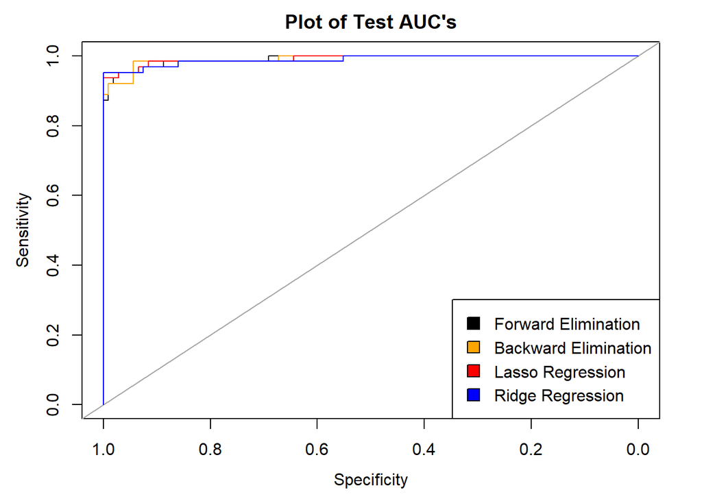

```r
legend("bottomright",
       c("Forward Elimination", "Backward Elimination", "Lasso Regression", "Ridge Regression"),
       fill = c("black", "orange", "red", "blue"))
```

Coparison between training and test AUC’s:

# Problem 3

## (a)

Read file GDM.raw.txt into a data table named gdm.dt, and store rsID and coded allele in a separate data table (call it snp.allele.dt). Impute missing values in gdm.dt according to SNP-wise average allele count.

```r
#read in the data table
gdm.dt <- data.table(read.delim("GDM.raw.txt"))


#separating the rsIDs and coded allele counts
colnames.list <- colnames(gdm.dt[, !c("ID", "sex", "pheno")])
snp.allele.dt <- as.data.table(matrix(unlist(lapply(colnames.list, function(x){strsplit(x,"_")})), ncol=2, byrow = TRUE))
colnames(snp.allele.dt)<- c("rsID","ref.allele")
snp.allele.dt[,coded.allele:=colnames(gdm.dt[, !c("ID", "sex", "pheno")])]


#impute to the mean
for (SNP.ref in colnames(gdm.dt[, !c("ID", "sex", "pheno")])) {
  #find missing values
  na.idx <- which(is.na(gdm.dt[[SNP.ref]])==TRUE)
  #assigning the mean
  gdm.dt[[SNP.ref]][na.idx] <- round(mean(gdm.dt[[SNP.ref]], na.rm = TRUE))
}
```

## (b)

Write function *univ.glm.test <- function(x, y, order=FALSE)* where x is a data table of SNPs, y is a binary outcome vector, and order is either TRUE or FALSE: the function should fit a logistic regression model for each SNP in x, and return a data table containing SNP names, regression coefficients, odds ratios, standard errors and p-values. If order is set to TRUE, the output data table should be ordered by increasing p-value.

```r
univ.glm.test <- function(x,y, order=FALSE){
  #x is a data table
  #y is a binary outcome vector

  stopifnot(nrow(x)==length(y))

  #output.dt <- data.table(SNP.name = NA, reg.coeff = NA, odds.ratio = NA, sd = NA, p.value = NA)

  SNP.names.vect <- c()
  slope.vect <- c()
  odds.ratio.vect <- c()
  sd.vect <- c()
  p.value.vect <- c()

  for (col in colnames(x)){
    #appending the column name
    SNP.names.vect <- c(SNP.names.vect, col)

    #reformatting the column of the dataframe to fit a model
    x.vect <- as.vector(unlist(x[[col]]))
    #fitting the model
    model <- glm(y ~ x.vect, family="binomial")

    #adding coefficient to the prepared vectors
    slope.vect <- c(slope.vect, summary(model)$coefficients[2])

    #adding the odds ratio
    odds.ratio.vect <- c(odds.ratio.vect, exp(summary(model)$coefficients[2]))

    #adding the standard error
    sd.vect <- c(sd.vect, summary(model)$coefficients[4])

    #adding the p-value
    p.value.vect <- c(p.value.vect ,summary(model)$coefficients[8])

    #constructing the output dataframe
    output.dt <- data.table(SNP.name = SNP.names.vect, reg.coeff = slope.vect, odds.ratio = odds.ratio.vect,
                            sd = sd.vect, p.value = p.value.vect)

  }

  if (order==TRUE){
    setorder(output.dt, p.value)
  }

  return(output.dt)
}
```

## (c)

Using function *univ.glm.test()*, run an association study for all the SNPs in gdm.dt against having gestational diabetes (column “pheno”). For the SNP that is most strongly associated to increased risk of gestational diabetes and the one with most significant protective effect, report the summary statistics from the GWAS as well as the 95% and 99% confidence intervals on the odds ratio.

```r
#removing ID, sex and phenotype from the data table to prepare for SNP model
proc.gdm.dt <- gdm.dt[,!c("ID", "sex", "pheno")]
pheno.vect <- gdm.dt$pheno
ordered.bol <- TRUE

#run the SNP association study
modeled.snp.dt <- univ.glm.test(proc.gdm.dt, pheno.vect, ordered.bol)

#only select significant SNP loci
sig.outcome.dt <- modeled.snp.dt[ which(modeled.snp.dt[,p.value< 5e-2]==TRUE)]

#finding the most protective coefficient
sig.outcome.dt[,.SD[which.min(reg.coeff)]]
```

```
##       SNP.name  reg.coeff odds.ratio        sd      p.value
## 1: rs2237897_T -0.4463906  0.6399338 0.1127141 7.483119e-05
```

```r
#95% confidence interval
beta <- sig.outcome.dt[,.SD[which.min(reg.coeff)]]$reg.coeff
se.beta <- sig.outcome.dt[,.SD[which.min(reg.coeff)]]$sd
round(exp(beta + 1.96 * se.beta * c(-1, 1)), 3)
```

```
## [1] 0.513 0.798
```

```r
#99% confidence interval
round(exp(beta + 2.58 * se.beta * c(-1, 1)), 3)
```

```
## [1] 0.478 0.856
```

```r
#summary statistics of coefficient with biggest risk factor
sig.outcome.dt[,.SD[which.max(reg.coeff)]]
```

```
##       SNP.name reg.coeff odds.ratio        sd    p.value
## 1: rs1423096_T 0.6510641    1.91758 0.3166547 0.03977583
```

```r
#95% confidence interval
beta2 <- sig.outcome.dt[,.SD[which.max(reg.coeff)]]$reg.coeff
se.beta2 <- sig.outcome.dt[,.SD[which.max(reg.coeff)]]$sd
round(exp(beta2 + 1.96 * se.beta2 * c(-1, 1)), 3)
```

```
## [1] 1.031 3.567
```

```r
#99% confidence interval
round(exp(beta2 + 2.58 * se.beta2 * c(-1, 1)), 3)
```

```
## [1] 0.847 4.341
```

## (d)

Merge your GWAS results with the table of gene names provided in file GDM.annot.txt (available on Learn). For SNPs that have p-value < 10−4 (hit SNPs) report SNP name, effect allele, chromosome number and corresponding gene name. Separately, report for each ‘hit SNP’ report the names of the gene that are within a 1Mb window from the SNP position on the chromosome. Note: That’s genes that fall within +/- 1,000,000 positions using the ‘pos’ column in the dataset.

```r
#read in the data table
annot.gdm.dt <- data.table(read.delim("GDM.annot.txt"))

#merge the modeled.snp.dt with allele names
gwas.prelim.dt <- merge(modeled.snp.dt, snp.allele.dt, by.x = "SNP.name", by.y = "coded.allele")
#merge the remaining two tables
gwas.dt <- merge(gwas.prelim.dt, annot.gdm.dt, by.x = "rsID", by.y = "snp")


#filtering hit alleles
hit.alleles <- gwas.dt[which(gwas.dt[,p.value<10e-4]==TRUE)]


#report SNP names, effect allele, chromosome number,gene name
hit.alleles[, c("SNP.name", "reg.coeff", "chrom", "gene")]
```

```
##        SNP.name  reg.coeff chrom   gene
## 1: rs12243326_A  0.6454198    10 TCF7L2
## 2:  rs2237892_C -0.4042888    11  KCNQ1
## 3:  rs2237897_T -0.4463906    11  KCNQ1
## 4:  rs3786897_A  0.4628940    19   PEPD
## 5:  rs4506565_T  0.4865711    10 TCF7L2
## 6:  rs7901695_T  0.4877117    10 TCF7L2
## 7:  rs7903146_C  0.4790441    10 TCF7L2
```

```r
#function that takes in a rsID, a data table with required fields and a full data table returns the genes within 1MB
#this function is not self dependent, however the best option to implement this problem
genes.finder <- function(hits, hit.alleles, gwas.dt){
  pos.hit <- hit.alleles[rsID==hits,pos]
  chrom.hit <- hit.alleles[rsID==hits, chrom]
  max.gen.pos <- pos.hit -1000000
  min.gen.pos <- pos.hit + 1000000
  chrom.alleles <- which(gwas.dt[ ,chrom == chrom.hit & (pos> max.gen.pos & pos<min.gen.pos)])
  return(unique(gwas.dt[which(gwas.dt[ ,chrom == chrom.hit & (pos> max.gen.pos)])]$gene))
}

#there are 7 hits, however only the first, second and fourth are unique
genes.finder(hit.alleles$rsID[1], hit.alleles, gwas.dt)
```

```
## [1] TCF7L2
## 96 Levels:  ABCC8 ADAMTS9-AS2 ADCY5 ADIPOR1 AGBL2 ALDH1A1 ALOX12-AS1 ... ZFAND3
```

```r
genes.finder(hit.alleles$rsID[2], hit.alleles, gwas.dt)
```

```
##  [1] TPH1  BDNF  TH    FAT3  AGBL2 CLPB  KCNQ1 MTCH2 STK33 ABCC8
## 96 Levels:  ABCC8 ADAMTS9-AS2 ADCY5 ADIPOR1 AGBL2 ALDH1A1 ALOX12-AS1 ... ZFAND3
```

```r
genes.finder(hit.alleles$rsID[4], hit.alleles, gwas.dt)
```

```
## [1] QPCTL    KIAA0355 PEPD     ZC3H4    IGFL2
## 96 Levels:  ABCC8 ADAMTS9-AS2 ADCY5 ADIPOR1 AGBL2 ALDH1A1 ALOX12-AS1 ... ZFAND3
```

## (e)

Build a weighted genetic risk score that includes all SNPs with p-value < 10−4, a score with all SNPs with p-value < 10−3, and a score that only includes SNPs on the FTO gene (hint: ensure that the ordering of SNPs is respected). Add the three scores as columns to the gdm.dt data table. Fit the three scores in separate logistic regression models to test their association with gestational diabetes, and for each report odds ratio, 95% confidence interval and p-value.

```r
#order the gwas table by SNP names in gdm columns
gwas.dt<- gwas.dt[order(match(SNP.name, colnames(gdm.dt)[-c(1,2,3)]))]

#ordering of SNPs
stopifnot(colnames(gdm.dt)[-c(1,2,3)] == gwas.dt$SNP.name)

#p.value < 10e-4
hit4 <- gwas.dt[p.value < 1e-4]
#columns of original table which come up as gwas significant
gdm.sig4.dt <- gdm.dt[, .SD, .SDcols = hit4$SNP.name]
#calculating the weighted score
weighted.score4.gwas <- as.matrix(gdm.sig4.dt) %*% hit4$reg.coeff
#adding the vector to the original data table
gdm.dt[, weighted4.scores := weighted.score4.gwas]
#fit logistic regression model
log.fit.weight4 <- glm(pheno ~ weighted4.scores ,data=gdm.dt, family="binomial")
#odds ratio
exp(summary(log.fit.weight4)$coefficients[2])
```

```
## [1] 2.727271
```

```r
#95% confidence interval
beta <- summary(log.fit.weight4)$coefficients[2]
se.beta <- summary(log.fit.weight4)$coefficients[4]
round(exp(beta + 1.96 * se.beta * c(-1, 1)), 3)
```

```
## [1] 1.919 3.877
```

```r
#p value
summary(log.fit.weight4)$coefficients[8]
```

```
## [1] 2.243725e-08
```

```r
#p.value < 10e-4
hit3 <- gwas.dt[p.value < 1e-3]
#columns of original table which come up as gwas significant
gdm.sig3.dt <- gdm.dt[, .SD, .SDcols = hit3$SNP.name]
#calculating the weighted score
weighted.score3.gwas <- as.matrix(gdm.sig3.dt) %*% hit3$reg.coeff
#adding the vector to the original data table
gdm.dt[, weighted3.scores := weighted.score3.gwas]
#fit logistic regression model
log.fit.weight3 <- glm(pheno ~ weighted3.scores,data=gdm.dt, family="binomial")
#odds ratio
exp(summary(log.fit.weight3)$coefficients[2])
```

```
## [1] 1.452815
```

```r
#95% confidence interval
beta <- summary(log.fit.weight3)$coefficients[2]
se.beta <- summary(log.fit.weight3)$coefficients[4]
round(exp(beta + 1.96 * se.beta * c(-1, 1)), 3)
```

```
## [1] 1.280 1.649
```

```r
#p value
summary(log.fit.weight3)$coefficients[8]
```

```
## [1] 7.029221e-09
```

```r
#FTO gene
hitfto <- gwas.dt[gene == "FTO"]
#columns of original table which come up as gwas significant
gdm.sigfto.dt <- gdm.dt[, .SD, .SDcols = hitfto$SNP.name]
#calculating the weighted score
weighted.scorefto.gwas <- as.matrix(gdm.sigfto.dt) %*% hitfto$reg.coeff
#adding the vector to the original data table
gdm.dt[, weightedFTO.scores := weighted.scorefto.gwas]
#fit logistic regression model
log.fit.weightfto <- glm(pheno ~ weightedFTO.scores,data=gdm.dt, family="binomial")
#odds ratio
exp(summary(log.fit.weightfto)$coefficients[2])
```

```
## [1] 1.413857
```

```r
#95% confidence interval
beta <- summary(log.fit.weightfto)$coefficients[2]
se.beta <- summary(log.fit.weightfto)$coefficients[4]
round(exp(beta + 1.96 * se.beta * c(-1, 1)), 3)
```

```
## [1] 0.818 2.445
```

```r
#p value
summary(log.fit.weightfto)$coefficients[8]
```

```
## [1] 0.2151883
```

## (f)

File GDM.test.txt (available on Learn) contains genotypes of other 40 pregnant women with and without gestational diabetes (assume that the reference allele is the same one that was specified in file GDM.raw.txt). Read the file into variable gdm.test. For the set of patients in gdm.test, compute the three genetic risk scores as defined at point (e) using the same set of SNPs and corresponding weights. Add the three scores as columns to gdm.test (hint: use the same column names as before).

```r
#read in the data
gdm.test.dt <- data.table(read.delim("GDM.test.txt"))

#order the gwas table by SNP names in gdm columns
gwas.dt<- gwas.dt[order(match(rsID, colnames(gdm.test.dt)[-c(1,2,3)]))]

#ordering of SNPs
stopifnot(colnames(gdm.test.dt)[-c(1,2,3)] == gwas.dt$rsID)

#columns of original table which come up as gwas significant
gdm.test.sig4.dt <- gdm.test.dt[, .SD, .SDcols = hit4$rsID]
#calculating the weighted score
weighted.test.score4.gwas <- as.matrix(gdm.test.sig4.dt) %*% hit4$reg.coeff
#adding the vector to the original data table
gdm.test.dt[, weighted4.scores := weighted.test.score4.gwas]
#outcome vector
outcome <- gdm.test.dt$pheno
#x weighted scores
x.weight.test.4 <- gdm.test.dt$weighted4.scores
#fit logistic regression model
log.fit.weight.test.4 <- glm(outcome ~ x.weight.test.4, family="binomial")
#odds ratio
exp(summary(log.fit.weight.test.4)$coefficients[2])
```

```
## [1] 10.45071
```

```r
#95% confidence interval
beta <- summary(log.fit.weight.test.4)$coefficients[2]
se.beta <- summary(log.fit.weight.test.4)$coefficients[4]
round(exp(beta + 1.96 * se.beta * c(-1, 1)), 3)
```

```
## [1]  1.572 69.493
```

```r
#p value
summary(log.fit.weight.test.4)$coefficients[8]
```

```
## [1] 0.01519353
```

```r
#columns of original table which come up as gwas significant
gdm.test.sig3.dt <- gdm.test.dt[, .SD, .SDcols = hit3$rsID]
#calculating the weighted score
weighted.test.score3.gwas <- as.matrix(gdm.test.sig3.dt) %*% hit3$reg.coeff
#adding the vector to the original data table
gdm.test.dt[, weighted3.scores := weighted.test.score3.gwas]
#x weighted scores
x.weight.test.3 <- gdm.test.dt$weighted3.scores
#fit logistic regression model
log.fit.weight.test.3 <- glm(outcome ~ x.weight.test.3, family="binomial")
#odds ratio
exp(summary(log.fit.weight.test.3)$coefficients[2])
```

```
## [1] 2.217313
```

```r
#95% confidence interval
beta <- summary(log.fit.weight.test.3)$coefficients[2]
se.beta <- summary(log.fit.weight.test.3)$coefficients[4]
round(exp(beta + 1.96 * se.beta * c(-1, 1)), 3)
```

```
## [1] 1.175 4.185
```

```r
#p value
summary(log.fit.weight.test.3)$coefficients[8]
```

```
## [1] 0.01400233
```

```r
#columns of original table which come up as gwas significant
gdm.test.sigfto.dt <- gdm.test.dt[, .SD, .SDcols = hitfto$rsID]
#calculating the weighted score
weighted.test.scorefto.gwas <- as.matrix(gdm.test.sigfto.dt) %*% hitfto$reg.coeff
#adding the vector to the original data table
gdm.test.dt[, weightedFTO.scores := weighted.test.scorefto.gwas]
#x weighted scores
x.weight.test.fto <- gdm.test.dt$weightedFTO.scores
#fit logistic regression model
log.fit.weight.test.fto <- glm(outcome ~ x.weight.test.fto, family="binomial")
#odds ratio
exp(summary(log.fit.weight.test.fto)$coefficients[2])
```

```
## [1] 1.962128
```

```r
#95% confidence interval
beta <- summary(log.fit.weight.test.fto)$coefficients[2]
se.beta <- summary(log.fit.weight.test.fto)$coefficients[4]
round(exp(beta + 1.96 * se.beta * c(-1, 1)), 3)
```

```
## [1]  0.157 24.529
```

```r
#p value
summary(log.fit.weight.test.fto)$coefficients[8]
```

```
## [1] 0.6009513
```

## (g)

Use the logistic regression models fitted at point (e) to predict the outcome of patients in gdm.test. Compute the test log-likelihood for the predicted probabilities from the three genetic risk score models.

```r
#789 predicted results
#predicting the testing outcomes
new4 <- data.frame(weighted4.scores = gdm.test.dt$weighted4.scores)
pred.weight4 <- predict(log.fit.weight4, newdata=new4, type="response")

new3 <- data.frame(weighted3.scores = gdm.test.dt$weighted3.scores)
pred.weight3 <- predict(log.fit.weight3, newdata=new3, type="response")

newfto <- data.frame(weightedFTO.scores = gdm.test.dt$weightedFTO.scores)
pred.weightfto <- predict(log.fit.weightfto, newdata=newfto, type="response")


#computing the log-likelihood
#p value < 10e-4
sum(log(pred.weight4[gdm.test.dt[,pheno==1]])) + sum(log(pred.weight4[gdm.test.dt[, pheno==0]]))
```

```
## [1] -27.76311
```

```r
#p value < 10e-3
sum(log(pred.weight3[gdm.test.dt[,pheno==1]])) + sum(log(pred.weight3[gdm.test.dt[, pheno==0]]))
```

```
## [1] -28.28168
```

```r
#gene FTO
sum(log(pred.weightfto[gdm.test.dt[,pheno==1]])) + sum(log(pred.weightfto[gdm.test.dt[, pheno==0]]))
```

```
## [1] -25.43476
```

## (h)

File GDM.study2.txt (available on Learn) contains the summary statistics from a different study on the same set of SNPs. Perform a meta-analysis with the results obtained at point (c) (hint: 4 remember that the effect alleles should correspond) and produce a summary of the meta-analysis results for the set of SNPs with meta-analysis p-value < 10−4 sorted by increasing p-value. (4 points)

```r
#read in the data
gwas2.dt <- fread("GDM.study2.txt")
gwas1.dt <- gwas.dt

#checking input file that all alleles are present
stopifnot(gwas1.dt$rsID %in% gwas2.dt$snp)
stopifnot(gwas2.dt$snp %in% gwas1.dt$rsID)

#order by snp/rsID
gwas1.dt <- gwas1.dt[order(rsID)]
gwas2.dt <- gwas2.dt[order(snp)]

#checking the ordering is the same
stopifnot(all.equal(gwas1.dt$rsID, gwas2.dt$snp))

#harmonizing the data
both.ok <- gwas1.dt$ref.allele == gwas2.dt$effect.allele
flipped <- gwas1.dt$ref.allele == gwas2.dt$other.allele
unmatched <- both.ok == flipped

table(both.ok, flipped)
```

```
##        flipped
## both.ok FALSE TRUE
##   FALSE     2   27
##   TRUE    147    0
```

```r
#it can be seen that 2 alleles do not match after flipping, these twwo are therefore discarded
gwas1.dt <- gwas1.dt[!which(unmatched==TRUE)]
gwas2.dt <- gwas2.dt[!which(unmatched==TRUE)]

both.ok2 <- gwas1.dt$ref.allele == gwas2.dt$effect.allele
flipped2 <- gwas1.dt$ref.allele == gwas2.dt$other.allele

table(both.ok2, flipped2)
```

```
##         flipped2
## both.ok2 FALSE TRUE
##    FALSE     0   27
##    TRUE    147    0
```

```r
#switching signs for second study
beta1 <- gwas1.dt$reg.coeff
beta2 <- gwas2.dt$beta
beta2[flipped2] <- -beta2[flipped2]

#meta analysis by inverse variance weighting
weight.gwas1 <- 1/gwas1.dt$sd^2
weight.gwas2 <- 1/gwas2.dt$se^2

head(weight.gwas1)
```

```
## [1] 95.95663 48.35218 51.12222 80.72417 32.39329 80.53452
```

```r
head(weight.gwas2)
```

```
## [1]  9.141470  6.919489  7.069651 10.430712  3.328963  9.751846
```

From the weighted scores, it seems like the first (original) study is more powered. Creating the meta-analysis effect size and summary table.

```r
#meta analysis effect size
beta.ma <- (weight.gwas1 *beta1 + weight.gwas2 * beta2)/(weight.gwas1+weight.gwas2)
se.ma <- sqrt(1/(weight.gwas1 + weight.gwas2))

#calculating p values
pval.ma <- 2* pnorm(abs(beta.ma/se.ma), lower.tail = FALSE)

#creating a summary table
ma.summary <- data.table(rsID = gwas1.dt$rsID, p.val = pval.ma, beta = beta.ma, se = se.ma )

#select significant p-values
sig.ma.summary <- ma.summary[p.val<1e-4]

#showing the ordered data table
sig.ma.summary[order(p.val)]
```

```
##          rsID        p.val       beta        se
## 1: rs12243326 2.851239e-15  0.8918988 0.1129379
## 2:  rs2237897 2.862805e-09 -0.5960910 0.1003642
## 3:  rs3786897 1.043301e-07  0.6069063 0.1141012
## 4:  rs2237892 5.858759e-06 -0.4834871 0.1066965
## 5:  rs4506565 3.287877e-05  0.5396749 0.1299622
## 6:  rs7903146 5.822054e-05  0.5353424 0.1331728
## 7:  rs7901695 8.256236e-05  0.5409567 0.1374089
```

# Problem 4

## (a)

Compute the matrix of correlations between the gene expression variables, and display it so that a block structure is highlighted. Write some code to identify the unique pairs of (distinct) variables that have correlation coefficient greater than 0.80 in absolute value and report their correlation coefficients.

```r
library(corrplot)
#load the data set
nki.dt <- data.table(read.csv("nki.csv", stringsAsFactors = TRUE))

#separate genes from remainder of data
gen.nki.dt <- nki.dt[, c(7:76)]

#compute the correlation matrix
gen.corr <- cor(gen.nki.dt[, .SD, .SDcols = sapply(gen.nki.dt, is.numeric)])

#in order to adjust the writing size on the axis, a png file has to be safed
png(height=1200, width=1500, pointsize=15, file="overlap.png")
corrplot(gen.corr, diag = FALSE, method = "color", title = "NKI Correlation Matrix", order = "AOE", tl.col = "black", number.cex = 1)
```

The correlation matrix for dataset NKI is displayed below. If the image does not display correctly, please either find the saved image “overlap.png” or comment out the line starting with png(…) above (the adjusted font size will go missing)

[figure not shown]

Identify the unique pairs of variables that have a correlation coefficient >0.8. My approach is based on the assumtion that no two correlation coefficients between two different variables are exactly equal. This assumption is reasonable since the correlation coefficients are recorded till the 8th significant figure which makes it highly unlikely that they would be the same.

```r
#create vectors for column and row names
r.nam <- row.names(gen.corr)
c.nam <- colnames(gen.corr)
#create vector that will hold the correlation coefficients that have been seen before
val.pair <- c()
#create opposite of %in%
`%notin%` <- Negate(`%in%`)

# Loop over gen.corr
for(row in 1:nrow(gen.corr)) {
    for(col in 1:ncol(gen.corr)) {
      #test if the correlation coefficient is greater than 0.8 (absolute)
      if(abs(gen.corr[row,col])>0.8){
        #test, if this is the correlation coefficient with itself
        if(row!=col){
          #test, if this correlation coefficient has been seen before
          if(gen.corr[row, col] %notin% val.pair){
            #print the results
            print(paste(r.nam[row], "and", c.nam[col], "have a correlation coefficient of",round(gen.corr[row, col],3)))
            #add the correlation coefficient to the list of correff, that have been seen before
            val.pair <- c(val.pair, gen.corr[row, col])
          }
        }
      }
    }
}
```

```
## [1] "DIAPH3 and DIAPH3.1 have a correlation coefficient of 0.803"
## [1] "DIAPH3 and DIAPH3.2 have a correlation coefficient of 0.834"
## [1] "NUSAP1 and PRC1 have a correlation coefficient of 0.83"
## [1] "DIAPH3.1 and DIAPH3.2 have a correlation coefficient of 0.887"
## [1] "PECI and PECI.1 have a correlation coefficient of 0.87"
## [1] "IGFBP5 and IGFBP5.1 have a correlation coefficient of 0.978"
## [1] "PRC1 and CENPA have a correlation coefficient of 0.818"
```

## (b)

Run PCA (only over the columns containing gene expressions) so that it is possible to identify variable clusters. Produce a scatter plot of the projection of the predictors on the first two principal components and report the percentage of variance explained by the first two components. Starting from the PCA plot just produced, devise a simple rule (hint: PC2<X ) that identifies the four gene expressions that are most different from the rest and report their names. Amount of variability explained by the first two principal components is 33%.

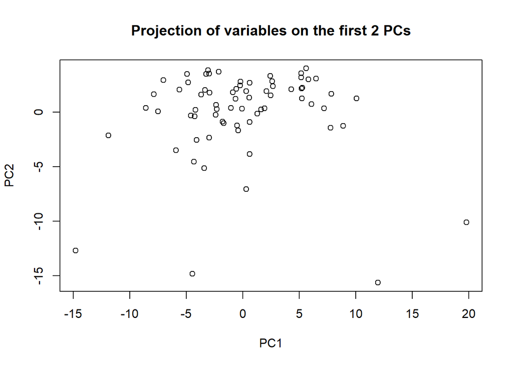

```r
#testing if elements are missing
stopifnot(is.na(gen.nki.dt)==0)

#run PCA
pca.gen <- prcomp(t(gen.nki.dt), scale=TRUE)

#Scatter plot
plot(pca.gen$x[, 1:2], main="Projection of variables on the first 2 PCs")
```

```r
#percentage of variance explained by the first two components
perc.expl.gen <- pca.gen$sdev^2 / sum(pca.gen$sdev^2)
sum(perc.expl.gen[1:2])
```

```
## [1] 0.3316167
```

```r
#Rule PA2<-10
#the 4 most different genes
pca.gen$x[which(pca.gen$x[, 2]<(-10)), .SD]
```

```
##
## SCUBE2
## MMP9
## ZNF533
## CDCA7
```

## (c)

Run PCA (only over the columns containing gene expressions) again, this time in order to derive a patient-wise summary of all gene expressions (dimensionality reduction), and only keep the first 3 principal components. Test if those principal components (independently) are associated with the outcome in unadjusted logistic regression models and in models adjusted for age, estrogen receptor and grade. Justify the difference in results between unadjusted and adjusted models.

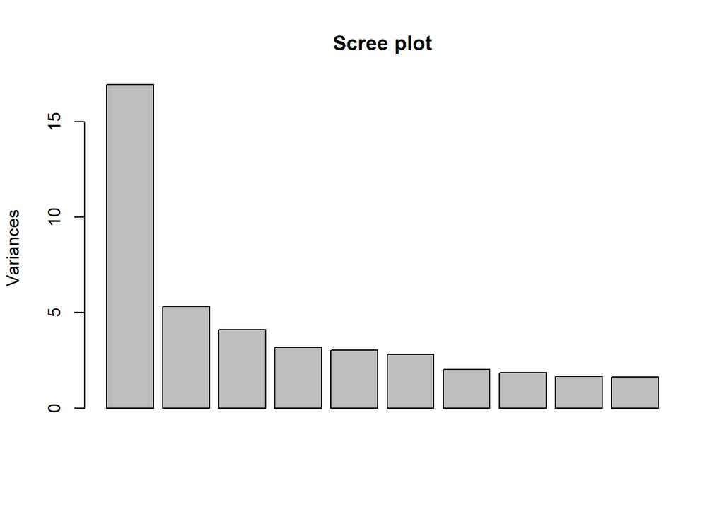

```r
#patient-wise PCA
pca.pats.gen <- prcomp(gen.nki.dt, scale=TRUE)

#Screeplot
screeplot(pca.pats.gen, main="Scree plot")
```

```r
#keeping the first three principal components
three.pat.pca <- pca.pats.gen$x[,1:3]

#unadjusted logistic regression
#PCA 1
un.pca1 <- glm(nki.dt$Event ~ three.pat.pca[,1], family="binomial")
#PCA 2
un.pca2 <- glm(nki.dt$Event ~ three.pat.pca[,2], family="binomial")
#PCA 3
un.pca3 <- glm(nki.dt$Event ~ three.pat.pca[,3], family="binomial")

#adjusted logistic regression age, estrogen receptor, grade
#PCA 1
ad.pca1 <- glm(nki.dt$Event ~ three.pat.pca[,1]+ nki.dt$Age+ nki.dt$EstrogenReceptor + nki.dt$Grade, family="binomial")
#PCA 2
ad.pca2<- glm(nki.dt$Event ~ three.pat.pca[,2]+ nki.dt$Age+ nki.dt$EstrogenReceptor + nki.dt$Grade, family="binomial")
#PCA 3
ad.pca3 <- glm(nki.dt$Event ~ three.pat.pca[,3]+ nki.dt$Age+ nki.dt$EstrogenReceptor + nki.dt$Grade, family="binomial")

summary(ad.pca1)
```

```
##
## Call:
## glm(formula = nki.dt$Event ~ three.pat.pca[, 1] + nki.dt$Age +
##     nki.dt$EstrogenReceptor + nki.dt$Grade, family = "binomial")
##
## Deviance Residuals:
##     Min       1Q   Median       3Q      Max
## -1.8482  -0.9038  -0.6372   1.1560   2.1881
##
## Coefficients:
##                                 Estimate Std. Error z value Pr(>|z|)
## (Intercept)                      2.88382    1.62175   1.778   0.0754 .
## three.pat.pca[, 1]               0.07216    0.06574   1.098   0.2724
## nki.dt$Age                      -0.07826    0.03565  -2.195   0.0282 *
## nki.dt$EstrogenReceptorPositive -0.03992    0.55452  -0.072   0.9426
## nki.dt$GradePoorly diff          0.18990    0.47058   0.404   0.6866
## nki.dt$GradeWell diff           -0.80401    0.53763  -1.495   0.1348
## ---
## Signif. codes:  0 '***' 0.001 '**' 0.01 '*' 0.05 '.' 0.1 ' ' 1
##
## (Dispersion parameter for binomial family taken to be 1)
##
##     Null deviance: 183.32  on 143  degrees of freedom
## Residual deviance: 168.04  on 138  degrees of freedom
## AIC: 180.04
##
## Number of Fisher Scoring iterations: 4
```

```r
#setting the seed
set.seed(1)

#separate the outcome and prepare dataset for lasso regression
ynki.dt <- as.matrix(nki.dt$Event)
xnki.dt <- prepare.glmnet(nki.dt, ~ . - Event)

#fit lasso regression
fit.cv.lasso <- cv.glmnet(xnki.dt, ynki.dt, family="binomial", type.measure="auc")

#running lasso regression only penalizing gene expression
#penalty = 1
#no penalty = 0
#preparing the penalty vector for lasso regression by setting the penalty for the first 5 columns (Diam-Age) to 0
pen <- c(rep(1, ncol(nki.dt)))
pen[c(1:5)] <- 0

#lasso regression which only penalizes genes(does not run)
pen.cv.lasso <- cv.glmnet(xnki.dt, ynki.dt, family="binomial", penalty.factor=pen, type.measure = "auc")
```

Results obtained at Sys.time() =2020-04-10 13:59:16 BST

```r
#AUC for unpenalized model
fit.cv.lasso$cvm[which(fit.cv.lasso$lambda == fit.cv.lasso$lambda.min)]
```

```
## [1] 0.7854173
```

```r
#AUC for penelized model
pen.cv.lasso$cvm[which(pen.cv.lasso$lambda == pen.cv.lasso$lambda.min)]
```

```
## [1] 0.7404656
```